# 3.15

Bingyan Liang

2023-02-22

## 3.15

We analyze the smoking cessation data described in Chapter 1. Descriptive statistics on patient baseline characteristics and event rates are summarized in Table 1.

## Table 1

```r
kable(tableone)
```

| X. | combination | patchOnly | Overall |
| --- | --- | --- | --- |
|  | (N=61) | (N=64) | (N=125) |
| age(years) |  |  |  |
| Mean (SD) | 50.0 (12.1) | 47.8 (11.5) | 48.8 (11.8) |
| Median [Min, Max] | 49.0 [25.0, 86.0] | 48.5 [22.0, 78.0] | 49.0 [22.0, 86.0] |
| sex |  |  |  |
| Female | 39 (63.9%) | 42 (65.6%) | 81 (64.8%) |
| Male | 22 (36.1%) | 22 (34.4%) | 44 (35.2%) |
| race |  |  |  |
| black | 15 (24.6%) | 23 (35.9%) | 38 (30.4%) |
| hispanic | 4 (6.6%) | 4 (6.3%) | 8 (6.4%) |
| other | 1 (1.6%) | 1 (1.6%) | 2 (1.6%) |
| white | 41 (67.2%) | 36 (56.3%) | 77 (61.6%) |
| employment status |  |  |  |
| full time | 34 (55.7%) | 38 (59.4%) | 72 (57.6%) |
| other | 20 (32.8%) | 19 (29.7%) | 39 (31.2%) |
| part time | 7 (11.5%) | 7 (10.9%) | 14 (11.2%) |
| smoking years |  |  |  |
| Mean (SD) | 31.9 (11.8) | 29.9 (11.5) | 30.9 (11.7) |
| Median [Min, Max] | 33.0 [10.0, 55.0] | 30.0 [9.00, 56.0] | 30.0 [9.00, 56.0] |
| level |  |  |  |
| heavy | 44 (72.1%) | 45 (70.3%) | 89 (71.2%) |
| light | 17 (27.9%) | 19 (29.7%) | 36 (28.8%) |
| past attempts |  |  |  |
| Mean (SD) | 20.6 (128) | 5.11 (12.4) | 12.7 (89.6) |
| Median [Min, Max] | 2.00 [0, 1000] | 2.50 [0, 100] | 2.00 [0, 1000] |
| nonsmoke(years) |  |  |  |
| Mean (SD) | 600 (1110) | 483 (1040) | 540 (1070) |
| Median [Min, Max] | 90.0 [0, 5480] | 90.0 [0, 6210] | 90.0 [0, 6210] |
| return rate(1/year) | 2.29951505870342 | 4.99421509334736 | 3.35818698347107 |

## Figure 1

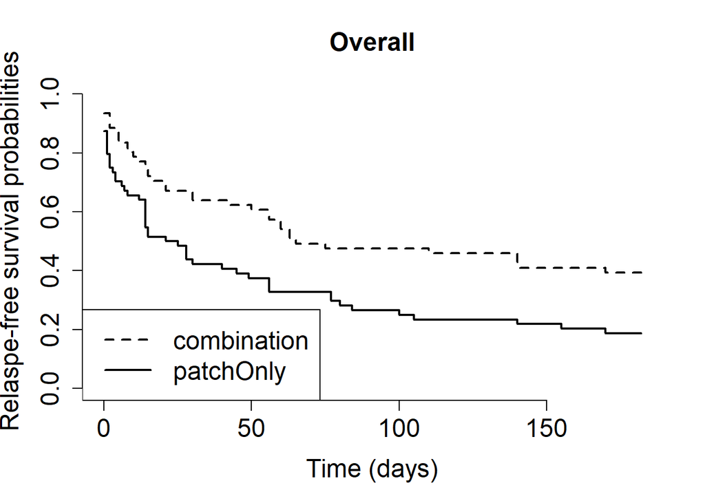

As preliminary analysis, the Kaplan-Meier curves for the composite endpoint are plotted by group in Figure 1. It is clear that combination groups acts betterthant the patchonly groups. To conduct a formal test on the effect of two treatments, we first use the standard unstratified log-rank test:

```r
## Unstratified log-rank test
survdiff(Surv(time,status)~trt,
         data=smoking)
```

```
## Call:
## survdiff(formula = Surv(time, status) ~ trt, data = smoking)
##
##                  N Observed Expected (O-E)^2/E (O-E)^2/V
## trt=combination 61       37     49.9      3.36      8.03
## trt=patchOnly   64       52     39.1      4.29      8.03
##
##  Chisq= 8  on 1 degrees of freedom, p= 0.005
```

Also, we conduct a log-rank test stratified by race:

```r
## Stratified log-rank test (by race)
survdiff(Surv(time,status)~trt+ strata(race),
         data=smoking)
```

```
## Call:
## survdiff(formula = Surv(time, status) ~ trt + strata(race), data = smoking)
##
##                  N Observed Expected (O-E)^2/E (O-E)^2/V
## trt=combination 61       37     49.1      2.98      7.06
## trt=patchOnly   64       52     39.9      3.66      7.06
##
##  Chisq= 7.1  on 1 degrees of freedom, p= 0.008
```

In summary, the two results suggested that, triple-combination pharmacotherapy has a highly significant beneficial effect on the relapse-free survival rate in smoking cessation, compared to standard-duration therapy.